# Курсовая работа № 2

## 4. Поиск гипотез зависимостей показателей таблицы "hr_dataset"

#### 4.1 Проверка возможных зависимостей по гендерному показателю

```python
# Показатели для графика приводятся по масштабу
hr33 = pd.read_sql("""SELECT
                            sex AS sex,
                            AVG(marriedid) AS marriedid,
                            AVG(perf_scoreid)/5 AS perf_scoreid,
                            AVG("Days Employed")/1000 AS days_employed,
                            AVG("Pay Rate")/20 AS Pay_Rate,
                            CAST( COUNT(*) AS float)/100 AS workin_now
                       FROM hr_dataset
                            WHERE "Employment Status"='Active'  AND  perf_scoreid < 9 AND perf_scoreid > 1
                                 GROUP BY sex
                                      ORDER BY days_employed
                                                             """, connect)
hr33.index = hr33.sex
hr33 = hr33.drop(['sex'], axis = 1)
hr33
```

| sex | marriedid | perf_scoreid | days_employed | pay_rate | workin_now |
| --- | --- | --- | --- | --- | --- |
| Male | 0.261538 | 0.630769 | 1.623492 | 1.820000 | 0.65 |
| Female | 0.390244 | 0.646341 | 1.770476 | 1.604262 | 0.82 |

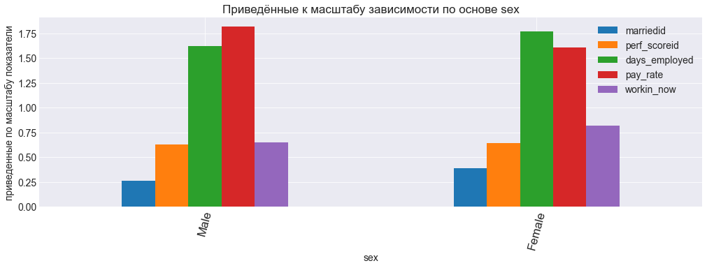

```python
plt.rcParams["figure.figsize"] = (17, 5)

matplotlib.rc('xtick', labelsize=17)
matplotlib.rc('ytick', labelsize=14)
plt.rcParams.update({'font.size': 14})

hr33.plot.bar()
plt.title("Приведённые к масштабу зависимости по основе sex", fontsize=17) # ШРИФТ
plt.ylabel('приведенные по масштабу показатели')
plt.xticks(rotation=75)
plt.show()
```

#### 4.1.1 Гендерные гипотезы

*1) Есть зависимость между полом работника и его семейным положением (на предприятии больше замужних женщин чем женатых мужчин)*  
*2) Есть зависимость между полом работника и его стажем (на предприятии у женщин стаж больше чем у мужчин)*  
*3) Есть зависимость между полом работника и его заработком (на предприятии у женщин заработок меньше чем у мужчин)*  
*4) Есть зависимость между полом работника и его квалификацией (на предприятии у женщин квалификация выше, чем у мужчин)*

#### 4.2 Проверка возможных зависимостей по принадлежности к расе

```python
# Показатели для графика приводятся по масштабу
hr34 = pd.read_sql("""SELECT
                            racedesc AS racedesc,
                            AVG(perf_scoreid)/2 AS race_perf_scoreid,
                            AVG("Pay Rate")/20 AS race_pay_rate
                       FROM hr_dataset
                            WHERE "Employment Status"='Active'
                                 GROUP BY  racedesc
                                      ORDER BY race_perf_scoreid
                                                                 """, connect)
hr34.index = hr34.racedesc
hr34 = hr34.drop(['racedesc'], axis = 1)
hr34
```

| racedesc | race_perf_scoreid | race_pay_rate |
| --- | --- | --- |
| Hispanic | 1.250000 | 2.900000 |
| Two or more races | 1.388889 | 1.768111 |
| Black or African American | 1.611111 | 1.791264 |
| Asian | 1.694444 | 1.649750 |
| White | 1.704348 | 1.643300 |
| American Indian or Alaska Native | 1.833333 | 1.575000 |

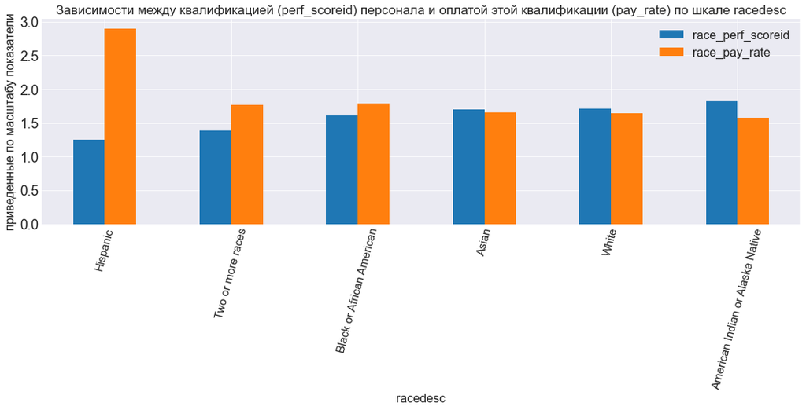

```python
plt.rcParams["figure.figsize"] = (18, 5)

matplotlib.rc('xtick', labelsize=15)
matplotlib.rc('ytick', labelsize=18)
plt.rcParams.update({'font.size': 16})

hr34.plot.bar()
plt.title("Зависимости между квалификацией (perf_scoreid) персонала и оплатой этой квалификации (pay_rate) по шкале racedesc", fontsize=17) # ШРИФТ
plt.ylabel('приведенные по масштабу показатели')
plt.xticks(rotation=75)
plt.show()
```

##### 4.2.1 Расовая гипотеза по соотношению квалификация / оплата

*1) Есть зависимость между средней квалификацией работников расы и оплатой: **чем ниже квалификация у расы, тем (К УДИВЛЕНИЮ) выше оплата**. Политкорректность одних или наглость (настоичивость) других?*